# Toto Data Analysis Project

Patrick Tan

2025-04-24

## **TOTO**

TOTO is a legalised form of lottery sold in Singapore that involves the drawing of numbers at random for a prize. While many countries ban any form of gambling including lottery, Singapore, known for its rigid legal system, legalised several forms of gambling, including lottery (TOTO, 4D, and Singapore Sweep), horsing racing, and sports betting.

TOTO was established in 1968 as a state-controlled channel of gambling to fight widespread illegal gambling in Singapore. Prior to 7th October 2014, it adopted a ‘6 out-of 45’ format. With a minimum betting amount of 50 cents, a buyer picks at least six numbers, from 1 to 45. The winning numbers drawn include six numbers plus an additional number. The game is played on every Monday and Thursday in Singapore. If the numbers chosen match at least three numbers and the additional number drawn, the player wins a prize.

For instance, if the player picked numbers 2, 7, 9, 14, 23 and 30, and the winning numbers drawn are: 2, 9, 14, 23, 30, 41 plus additional number 7, the player will win a prize for the 5+1 category (for matching 5 out of 6 winning numbers, and the additional number drawn).

The winners will get a share of the prize pool for each draw (“Prize Pool”). The Prize Pool shall be an amount equal to fifty-four per cent (54%) of the net amount of total stake collection of that draw less the Goods and Services Tax thereon . Please refer to Exhibit 1 for the shares of the prize pool by different prize groups.

If there is more than 1 winner in a prize group, the prize amount will be divided equally among all winners. (Applicable to Group 1, 2, 3 and 4).

## **Snowballing of Prize**

In 1981, snowballing was introduced to TOTO. It worked as the following:

• If there is no winner in Group 1 to 4, the prize amount will snowball (i.e. it gets added to the next draw prize amount).  
• Group 1 Prize will snowball up to 4 draws, whereas, the Group 2, 3 and 4 will snowball until they are won.  
• If there is no winner for 4 consecutive draws, the Group 1 Prize will cascade to the Group 2 Prize, to be shared equally among the winners.  
• If there is no winner in Group 2, it will cascade to the next Group until there is a winner.  
• Cascading only applies to Group 1 Prize.

## **Bet Types**

Players can bet on TOTO in the following ways:

• Ordinary Entry: This is the most basic bet. Each Ordinary Entry costs $0.50.  
• System Entry: Select more than 6, and up to 12 numbers from 1 to 45. E.g. System 7 bet is a selection of 7 numbers. System 8 has 8 numbers, and so on.  
• System Roll: Select 5 numbers from 1 to 45. The last number is represented by ‘R’, covers the remaining 40 numbers.  
• QuickPick: The computer randomly selects numbers from 1 to 45.

## **Prize Table**

**📋 Click to view prize group table**

| Prize Group | Winning Numbers Matched | Prize Amount |
| --- | --- | --- |
| **1** | 6 numbers | 33% of prize pool |
| **2** | 5 numbers plus the additional number | 13% of prize pool |
| **3** | 5 numbers | 13% of prize pool |
| **4** | 4 numbers plus the additional number | 13% of prize pool |
| **5** | 4 numbers | $30 per winning combination |
| **6** | 3 numbers plus the additional number | $20 per winning combination |

## **Assumptions 💡**

1. We are only analyzing winners from Group 1
2. Dataset only covers from 1997 to 2014; GDP Per Capita dataset covers from 1990 to 2020
3. Sample Betting Number only provides Punters Bet Combination on 1997-08-14
4. Betting Amount is taken as the revenue since Group1.Prize is derived from the total bet amounts by all the bets placed by punters (Neglecting any cost to run Toto System or other sources of revenue)
5. Only 1 Bet Type is assumed in this analysis - **Ordinary Bet**

## **Dataset used for analysis 💾**

#### [Outlet Betting Result] - [Date, Outlet, No.Bets, No.Winners]

#### [Sample Betting Number] - [No, Date, Betting.Num]

#### [Singapore GDP Per Capita Historical Data] - [Year, GDP Per Capita]

#### [Singapore Pools Outlets] - [No, Outlet, Address]

#### [TOTO_Result] - [Date, Draw.No, Winning.Numbers, Additional.Number, Group1.Prize, Num.Winners, Draw]

## **Problem Statements ❓**

* Ideally, with these problem statements it serves as a guidance for analysis to look into the data for meaningful insights that can be make sense of which hopefully can be converted into actionable strategy recommendations as well as provide general informative report for how Toto system has been fairing.  
** This analysis is also limited by the datasets that I have therefore the result of this analysis should not be used in real-world but as a means of educational purpose only.

1. Total Bets over GDP Per Capita Per Year [Informative]  
2. Total Bet Amount over GDP Per Capita Per Year [Informative]  
3. If you are a punter, which Singapore Pools outlet will you go to try your luck?  
4. Is there any pattern in punters’ behavior in betting the numbers?  
5. Top 10 Popular Numbers pick in **1997-08-14** [Informative]  
6. Does Punters bet more when Prizes start to snowball?  
7. What can Singapore Pools do increase their revenues? *  
8. What are the key factors affecting TOTO revenues? *

* *Open-ended questions that requires more analysis and data available to provide strong basis for recommendations.*

## 1. Importing Relevant Libraries

```r
library(dplyr)
```

```r
library(readxl)
library(ggplot2)
library(tidyr)
library(stringr)
library(dplyr)
library(gganimate)
library(lubridate)
library(broom)
library(kableExtra)
library(ggthemes)
```

## 2. Reading Dataset and Preparing Dataset for Analysis

```r
### Analysing the Dataset and Understanding the Dataset ###

betting.result <- read.csv("./Dataset/Toto/Outlet Betting Result.csv")
head(betting.result,5) #Everyday's betting result is recorded for its no.of bets & winner throughout 83 outlets
```

```
##         Date Outlet No.Bets No.Winners
## 1 1997-07-03      1  443921          0
## 2 1997-07-03      2   59364          0
## 3 1997-07-03      3   50397          0
## 4 1997-07-03      4   51975          0
## 5 1997-07-03      5   61591          0
```

```r
samplebettingnumbers <- read.csv("./Dataset/Toto/Sample Betting Numbers.csv")
head(samplebettingnumbers,5) #shows 50,000 sample betting numbers from a certain date "1997-08-14"
```

```
##   No       Date       Betting.Num
## 1  1 1997-08-14 34 44 11 26 36 21
## 2  2 1997-08-14   43 18 23 2 3 24
## 3  3 1997-08-14 16 22 26 13 21 20
## 4  4 1997-08-14   30 9 17 35 2 32
## 5  5 1997-08-14   42 3 2 45 38 20
```

```r
sg.gdp <- read_xlsx("./Dataset/Toto/Singapore GDP Per Capita Historical Data.xlsx")
head(sg.gdp,5) #GDP per capita from 1990 to 2020
```

```
## # A tibble: 5 × 2
##    Year `GDP Per Capita`
##   <dbl>            <dbl>
## 1  1990            11862
## 2  1991            14502
## 3  1992            16136
## 4  1993            18290
## 5  1994            21553
```

```r
pool.outlets <- read.csv("./Dataset/Toto/Singapore Pools Outlets.csv",fileEncoding = "latin1")
head(pool.outlets,5) #Gives more detail to the 83 outlets
```

```
##   No                                 Outlet
## 1  1  Singapore Pools Anchorvale Rd Branch
## 2  2  Singapore Pools Ang Mo Kio N2 Branch
## 3  3 Singapore Pools Ang Mo Kio N2A Branch
## 4  4  Singapore Pools Ang Mo Kio N4 Branch
## 5  5  Singapore Pools Ang Mo Kio N6 Branch
##                                                      Address
## 1           Blk 308 Anchorvale Rd #01-05    Singapore 540308
## 2 Blk 202 Ang Mo Kio Ave 3 #01-1662/1664    Singapore 560202
## 3      Blk 226A Ang Mo Kio Ave 1 #01-625    Singapore 561226
## 4     Blk 447 Ang Mo Kio Ave 10 #01-1685    Singapore 560447
## 5       Blk 630 Ang Mo Kio Ave 4 #01-968    Singapore 560630
```

```r
totoresults <- read.csv("./Dataset/Toto/TOTO_Result.csv")
head(totoresults,5) #1802 Draws till 2014
```

```
##        Date Draw.No   Winning.Numbers Additional.Number Group1.Prize
## 1  3/7/1997       1  44 13 23 32 36 2                 8       745372
## 2  7/7/1997       2  23 33 1 15 44 34                22       778601
## 3 10/7/1997       3 26 29 12 17 34 24                28       770587
## 4 14/7/1997       4  21 1 26 25 30 17                40       672187
## 5 17/7/1997       5  37 23 2 34 43 32                 8       713360
##   Num.Winners Draw
## 1           1    1
## 2           1    1
## 3           1    1
## 4           4    1
## 5           1    1
```

```r
# No Missing Data found #

#### Cleaning Pool Outlets before Manipulation ###
temp <- separate(pool.outlets,Address,into=c("Address", "Postal Code"),sep="Singapore")
temp[26,3] <- pool.outlets[26,3]
temp[26,3] <- str_remove(temp[26,3],"Singapore 738078")
temp[26,4] <- "738078"

#### Reducing Number of Dataset to work with ####

betting.resultv2<-left_join(betting.result,temp,by=c("Outlet"="No"))
colnames(betting.resultv2) <- c("Date","Outlet No.","No.Bets","No.Winners","Outlet Name","Address","Postal Code")
head(betting.resultv2,5)
```

```
##         Date Outlet No. No.Bets No.Winners
## 1 1997-07-03          1  443921          0
## 2 1997-07-03          2   59364          0
## 3 1997-07-03          3   50397          0
## 4 1997-07-03          4   51975          0
## 5 1997-07-03          5   61591          0
##                              Outlet Name
## 1  Singapore Pools Anchorvale Rd Branch
## 2  Singapore Pools Ang Mo Kio N2 Branch
## 3 Singapore Pools Ang Mo Kio N2A Branch
## 4  Singapore Pools Ang Mo Kio N4 Branch
## 5  Singapore Pools Ang Mo Kio N6 Branch
##                                      Address Postal Code
## 1           Blk 308 Anchorvale Rd #01-05          540308
## 2 Blk 202 Ang Mo Kio Ave 3 #01-1662/1664          560202
## 3      Blk 226A Ang Mo Kio Ave 1 #01-625          561226
## 4     Blk 447 Ang Mo Kio Ave 10 #01-1685          560447
## 5       Blk 630 Ang Mo Kio Ave 4 #01-968          560630
```

### Question 1: Total Bets over GDP Per Capita Per Year [Informative]

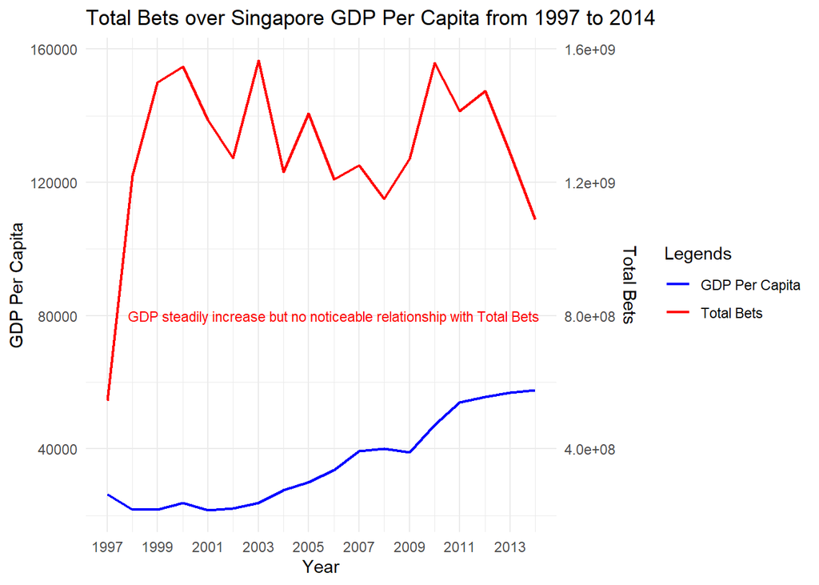

```r
#Configure date to show year
year <- substr(betting.resultv2$Date,1,4)
betting.resultv2$Year <- year #Adding Year Column
betting.resultv2$Year <- as.numeric(betting.resultv2$Year)
plot1_df <- betting.resultv2 %>% group_by(Year) %>% summarise(Total_Bets = sum(No.Bets)) %>% merge(sg.gdp, by.x = 'Year', by.y='Year') #Preparing plot dataframe
# plot1_df

#Plotting
plot1 <- ggplot(plot1_df) + geom_line(aes(x=Year,y=`GDP Per Capita`,color="GDP Per Capita"),size=0.8) + geom_line(aes(x=Year,y=Total_Bets/10000, color="Total Bets"),size=0.8) +scale_y_continuous(sec.axis= sec_axis(~.*10000,name="Total Bets")) + scale_color_manual(values = c("GDP Per Capita" = "blue", "Total Bets" = "red")) + labs(color = "Legends") + scale_x_continuous(breaks=seq(1997,2014,by=2)) + labs(title="Total Bets over Singapore GDP Per Capita from 1997 to 2014") +annotate("text", x = 2006, y = 80000, label = "GDP steadily increase but no noticeable relationship with Total Bets", color = "red",size=3) +theme_minimal()
plot1
```

### Question 2: Total Bet Amount over GDP Per Capita Per Year [Informative]

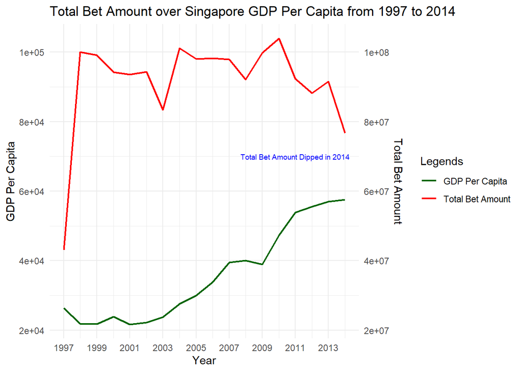

```r
#Retrieving Betting Amount
plot2_betamt <- totoresults %>% mutate(bettingamount = ifelse(Draw!=1,Group1.Prize-lag(Group1.Prize,default= first(Group1.Prize)),Group1.Prize)) %>% mutate(Date= as.Date(Date,format="%d/%m/%Y"),Year = format(Date,"%Y"))
plot2_betamt$Year <- as.numeric(plot2_betamt$Year)

#Preparing Plot Dataset
plot2_df <- plot2_betamt %>% group_by(Year) %>% summarise(total_bet_amt = sum(bettingamount)) %>% merge(sg.gdp,by.x='Year',by.y='Year')
# plot2_df

#Plotting
plot2 <- ggplot(plot2_df) + geom_line(aes(x=Year,y=`GDP Per Capita`, color = "GDP Per Capita"),size=0.8) + geom_line(aes(x=Year,y=total_bet_amt/1000,color="Total Bet Amount"),size=0.8) + scale_y_continuous(sec.axis=sec_axis(~.*1000, name = "Total Bet Amount")) + scale_color_manual(values = c("GDP Per Capita" = "darkgreen", "Total Bet Amount" = "red")) + labs(color = "Legends") +scale_x_continuous(breaks=seq(1997,2014,by=2)) +annotate("text",x=2011,y=70000,label = "Total Bet Amount Dipped in 2014",size=2.5,color="blue") +labs(title="Total Bet Amount over Singapore GDP Per Capita from 1997 to 2014") + theme_minimal()
plot2
```

### Question 3: If you are a punter, which Singapore Pools outlet will you go to try your luck?

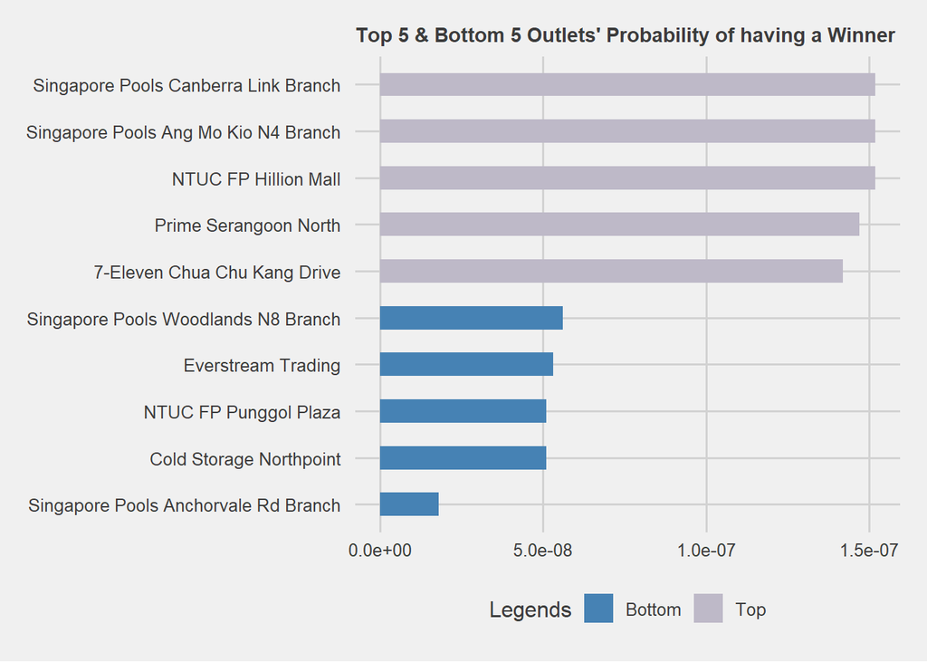

```r
### Finding top 5 and bottom 5 outlets' probability of having winners ###
plot3_df <- betting.resultv2 %>% group_by(`Outlet Name`) %>% summarise(Prob =round(sum(No.Winners)/sum(No.Bets),9))%>% arrange(desc(Prob))
plot3_df.top <- plot3_df %>% slice_head(n=5) %>% mutate(rank="Top")
plot3_df.bottom <- plot3_df %>% slice_tail(n=5) %>% mutate(rank="Bottom")

plot3_df.ranked <- rbind(plot3_df.top,plot3_df.bottom)
plot3_df.ranked$rank <- as.factor(plot3_df.ranked$rank)
# plot3_df.ranked

#Preparing Plot Dataset
plot3 <- plot3_df.ranked %>% ggplot(aes(x=reorder(`Outlet Name`,Prob))) + geom_bar(aes(y=Prob,fill=rank),stat='identity',width=0.5) +coord_flip() +xlab('Outlets') + ylab('Probability of Winning') +labs(title="Top 5 & Bottom 5 Outlets for Probability of Winners",fill="Legends") + scale_fill_manual(values=c("Bottom"="steelblue","Top"="#beb9c8"))+ labs(title = "Top 5 & Bottom 5 Outlets' Probability of having a Winner") + theme_fivethirtyeight() + theme(plot.title = element_text(size = 11))

plot3
```

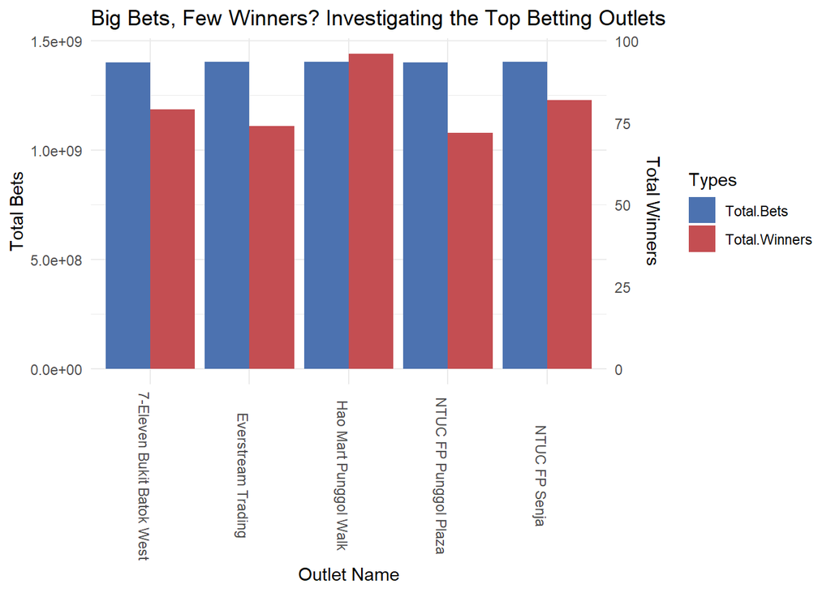

```r
################### It is more significant and if an outlet has 50,000 bets and 4 winners than outlets with 1 million bets and 7 winners.

### Combine all the winners from each outlet and measure it against total bets (Relative) ###
winsdf <-betting.resultv2 %>% group_by(`Outlet Name`) %>% summarise(Total.Winners = sum(No.Winners)) %>% arrange(desc(Total.Winners)) %>% slice_head(n=5)
betsdf <- betting.resultv2 %>% group_by(`Outlet Name`) %>% summarise(Total.Bets = sum(No.Bets)) %>% arrange(desc(Total.Bets)) %>% slice_head(n=5)

#Merging
win_betdf <- winsdf %>% merge(betsdf, by.x= 'Outlet Name',by.y='Outlet Name')


#Preparing Plot Dataset
plot3_altdf <- win_betdf %>% pivot_longer(cols = c(Total.Bets, Total.Winners),names_to = "type",values_to = "amount") %>% mutate(scaled_bets = round(ifelse(type=="Total.Winners",amount*15000000,amount),2))

plot3_alt <- plot3_altdf %>% ggplot(aes(x=`Outlet Name`, y=scaled_bets, fill = type)) + geom_bar(stat='identity',position='dodge') + scale_y_continuous(name= "Total Bets",sec.axis=sec_axis(~./15000000, name="Total Winners")) + theme_minimal() + theme(axis.text.x = element_text(angle=270)) + scale_fill_manual(values = c("Total.Bets" = "#4c72b0","Total.Winners" = "#c44e52")) + labs(title="Big Bets, Few Winners? Investigating the Top Betting Outlets",fill="Types")

plot3_alt
```

### Question 4: Is there any pattern in punters’ behavior in betting the numbers?

*It is important we do our research and check our dataset carefully before analyzing and making false conclusions 🧠*  
* This dataset contains all the sample numbers from 1 to 45 ONLY (Before the increase to 49 numbers)  
* Winning Number Result also contains all the winning numbers up till before the change happens

```r
#Sorting Sample Betting Numbers into Columns for analysis
punters_num <- separate(samplebettingnumbers,`Betting.Num`, into= c("Num1","Num2","Num3","Num4","Num5","Num6"), sep=" ")
punters_num <- cbind(punters_num, samplebettingnumbers$Betting.Num)
punters_num <- punters_num[,c(1,2,9,3:8)]
colnames(punters_num)[3] <- "Betting.Num"


#Classification Function to park Numbers into Buckets
classification <- function(x){
  return(as.vector(cut(as.integer(x),breaks=c(0,10,20,30,40,50), labels=c("<10","10s","20s","30s","40s"),right=FALSE))) #right=F -> closed on left open on right
}

#Classifying the numbers into groups using function
punters_num <- punters_num %>% mutate(Date=format(as.Date(punters_num$Date, format = "%Y-%m-%d"),"%d/%m/%Y"),across(.cols=starts_with("Num"),classification))

#Pivot wide to long for plotting
punters_num <- punters_num %>% select(starts_with("Num")) %>% pivot_longer(cols = everything(),names_to = "Num", values_to = "Interval" ) %>% group_by(Num,Interval) %>% summarise(Count = n())
```

[output not shown]

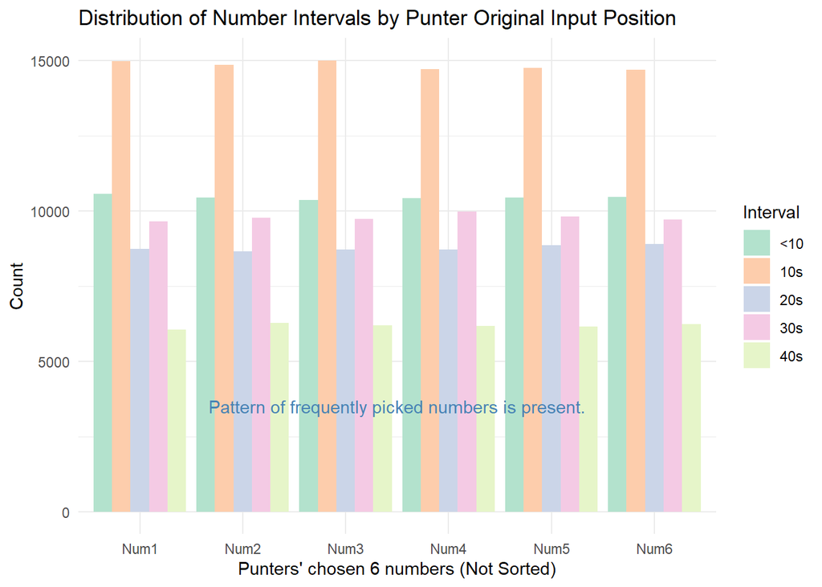

```r
plot4 <- ggplot(punters_num,aes(x=Num,y=Count,fill=Interval)) + geom_bar(stat='identity',position ='dodge') + scale_fill_brewer(palette= "Pastel2") + xlab("Punters' chosen 6 numbers (Not Sorted)") + labs(title= "Distribution of Number Intervals by Punter Original Input Position") + annotate("text",x=3.5, y=3500,label="Pattern of frequently picked numbers is present.",color="steelblue") +theme_minimal()
plot4
```

```r
#### Comparing it with Actual Toto Result
actualresults <- separate(totoresults,`Winning.Numbers`,into=c(paste0("Num",1:6)),sep=" ")
actualresults <- cbind(actualresults,totoresults$Winning.Numbers)
actualresults <- actualresults[,c(1,2,13,3:12)]
colnames(actualresults)[3] <- "Winning.Numbers"

#Classifying the numbers into groups using function
actualresults <- actualresults %>% mutate(Date=as.Date(actualresults$Date,format="%d/%m/%Y"), across(.cols=starts_with("Num"),classification))

#Pivot wide to long for plotting
actualresults <- actualresults %>% select(Num1,Num2,Num3,Num4,Num5,Num6) %>% pivot_longer(cols=everything(), names_to= "Num",values_to="Interval") %>% group_by(Num,Interval) %>% summarise(Count=n())
```

[output not shown]

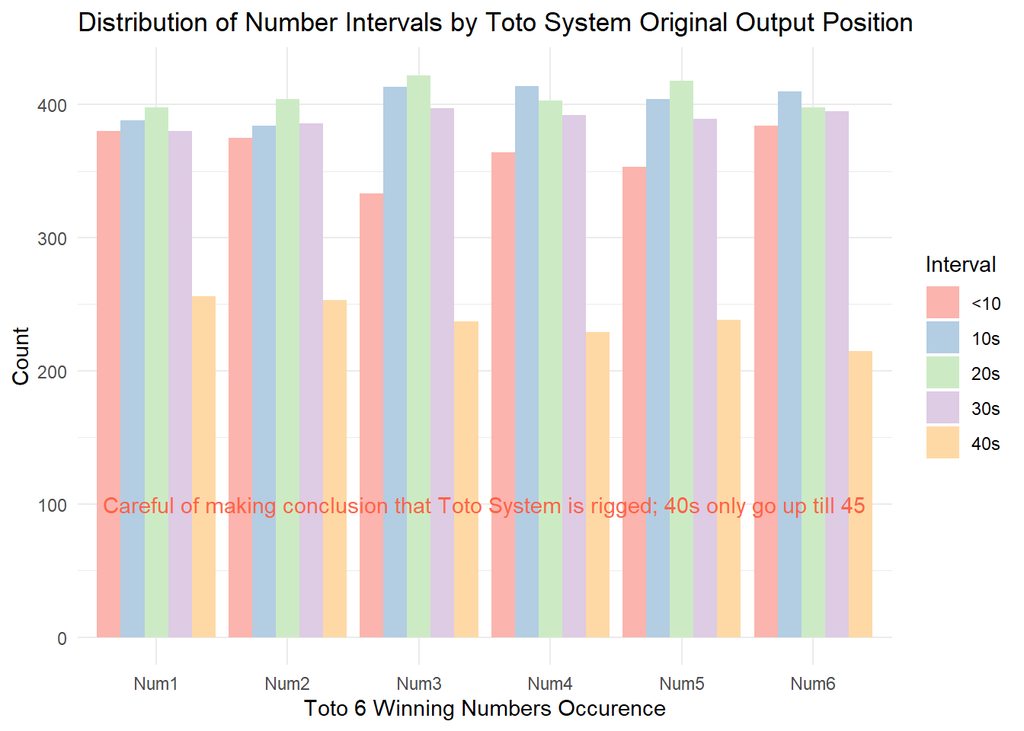

```r
plot4_alt <- ggplot(actualresults,aes(x=Num,y=Count,fill=Interval)) +geom_bar(stat='identity',position='dodge') +scale_fill_brewer(palette="Pastel1") + xlab("Toto 6 Winning Numbers Occurence") + labs(title="Distribution of Number Intervals by Toto System Original Output Position") + annotate("text",x=3.5,y=100,label="Careful of making conclusion that Toto System is rigged; 40s only go up till 45", color="tomato") +theme_minimal()
plot4_alt
```

### If we run a Chi-Sq Test

```r
##### Actual Toto Result suggest unfairness in the drawn numbers #####

observed <- actualresults %>%
  group_by(Interval) %>%
  summarise(Count = sum(Count)) %>%
  arrange(Interval)
observed
```

```
## # A tibble: 5 × 2
##   Interval Count
##   <chr>    <int>
## 1 10s       2413
## 2 20s       2443
## 3 30s       2339
## 4 40s       1428
## 5 <10       2189
```

```r
total_drawn <- sum(observed$Count)
expected <- rep(total_drawn / 5, 5)  # equal expectation for each interval


plot4_alt.chitest <- chisq.test(x = observed$Count, p = rep(1/5, 5))
plot4_alt.chitest
```

```
##
##  Chi-squared test for given probabilities
##
## data:  observed$Count
## X-squared = 329.62, df = 4, p-value < 2.2e-16
```

#### *It does suggest unfairness in the drawn numbers, but take note the dataset only runs until right before the change in Toto system from 1-45 to 1-49. Therefore there are fewer numbers in 40s, making the occurence of 40s being picked look significantly lower*

### Question 5: Top 10 Popular Numbers pick in **1997-08-14** [Informative]

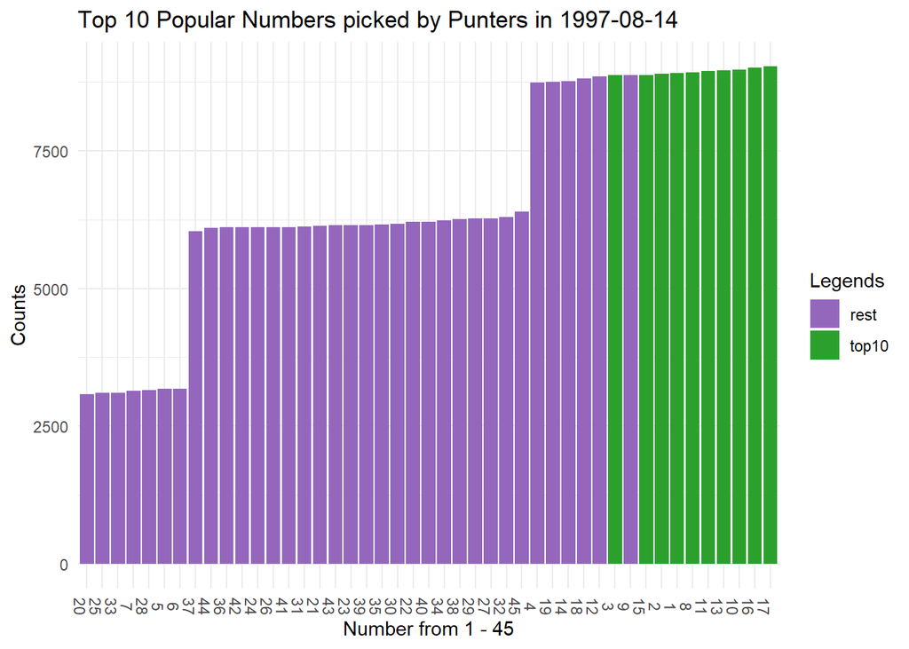

```r
#Sorting out Dataset for analysis
punters_bets <- separate(samplebettingnumbers,`Betting.Num`, into= c("Num1","Num2","Num3","Num4","Num5","Num6"), sep=" ")
punters_bets <- cbind(punters_bets, samplebettingnumbers$Betting.Num)
punters_bets <- punters_bets[,c(1,2,9,3:8)]
colnames(punters_bets)[3] <- "Betting.Num"
# punters_bets

#Pivot from wide to long
punter_bets <- punters_bets %>% select(starts_with("Num")) %>% pivot_longer(cols=everything(),names_to="Number",values_to="num") %>% select(num) %>% group_by(num) %>% summarise(count=n()) %>% arrange(as.integer(num))

#Ranking the results
plot4_alt2df.top10 <- punter_bets %>% arrange(desc(count)) %>% slice_head(n=10) %>% mutate(rank="top10")
plot4_alt2df.rest <- punter_bets %>% arrange(desc(count)) %>% slice(-1:-10) %>% mutate(rank="rest")

#Merging the results
plot4_alt2df <- rbind(plot4_alt2df.top10,plot4_alt2df.rest)

#Plotting
plot4_alt2 <- plot4_alt2df %>% arrange(num) %>% ggplot(aes(x=reorder(num,count),y=count)) + geom_bar(aes(fill=rank),stat='identity') + scale_fill_manual(values=c("top10"="#2ca02c","rest"="#9467bd")) + theme_minimal() +xlab("Number from 1 - 45") + labs(title="Top 10 Popular Numbers picked by Punters in 1997-08-14",fill="Legends") +theme(axis.text.x= element_text(angle=270)) +ylab("Counts")
plot4_alt2
```

### Question 6: Does Punters bet more when Prizes start to snowball?

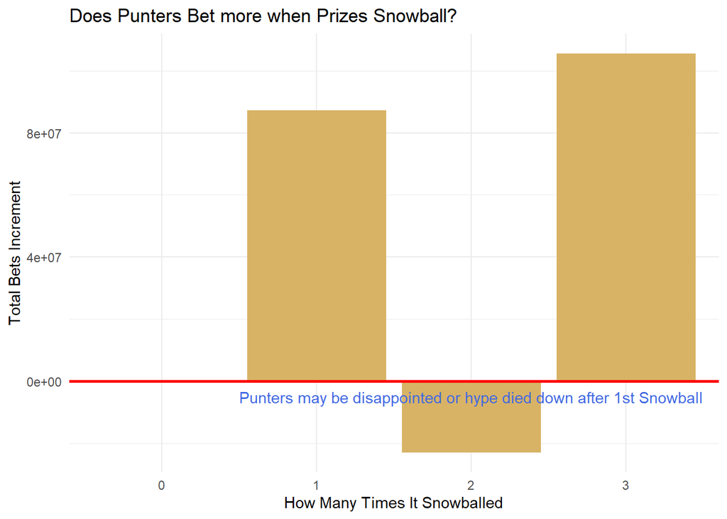

```r
#Sorting Dataset for Analysis + Adding relevant columns
toto.R <- totoresults %>% mutate(bettingamount = ifelse(Draw!=1,Group1.Prize-lag(Group1.Prize,default= first(Group1.Prize)),Group1.Prize), snowball = as.factor(ifelse(Draw!=1,Draw-1,0)),Date=as.Date(Date,format="%d/%m/%Y"))

betting.R <- betting.resultv2 %>% mutate(Date=as.Date(Date,format="%Y-%m-%d")) %>% group_by(Date) %>% summarise(Total.Bets = sum(No.Bets))


#Merging Dataset
snowball_df <- toto.R %>% left_join(betting.R, by="Date")
snowball_df <- snowball_df %>% mutate(Bets.Increment = ifelse(snowball!=0,Total.Bets-lag(Total.Bets,default=first(Total.Bets)),0)) %>% select(Date,Group1.Prize,Num.Winners,Draw,bettingamount,snowball,Total.Bets,Bets.Increment)

#Preparing Plot Dataset
plot5_alt <- snowball_df %>% group_by(snowball) %>% summarise(total.bets.increment = sum(Bets.Increment)) %>% ggplot(aes(x=snowball,y=total.bets.increment)) + geom_bar(stat='identity',fill="#d8b365")

#Plotting
plot5_alt +  geom_hline(yintercept = 0, color = "red",size=1) + xlab("How Many Times It Snowballed") +ylab("Total Bets Increment") + labs(title="Does Punters Bet more when Prizes Snowball?") + theme_minimal() + annotate("text", x=3,y=-5000000,label="Punters may be disappointed or hype died down after 1st Snowball", color="royalblue",size=3.8)
```

### Question 6 Extra: Notice there wasn’t a clear linear relationship between Punters Betting Behavior and Snowball Effects

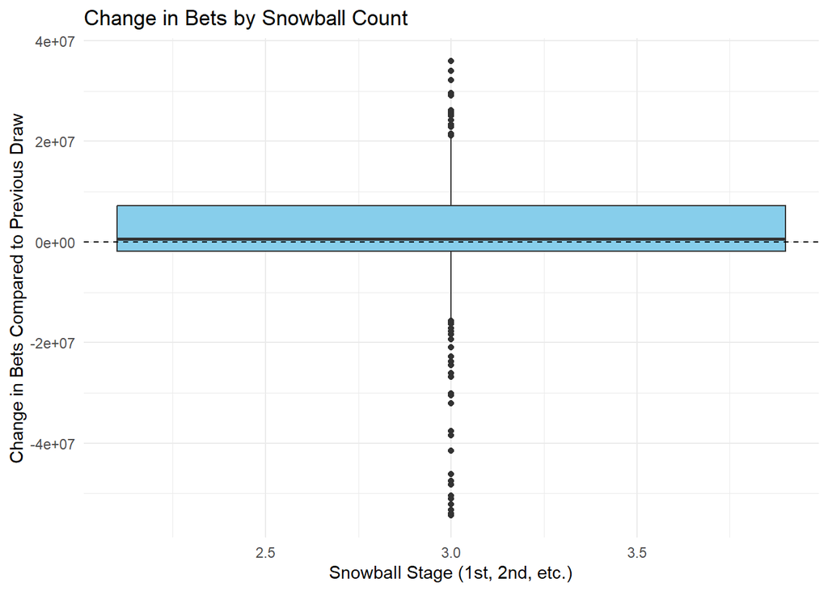

```r
## Changes in Raw Bets by Snowball Count ##
plot6_1 <- ggplot(snowball_df %>% filter(snowball != 0),
       aes(x = as.integer(snowball), y = Bets.Increment,group=1)) +
  geom_boxplot(fill = "skyblue") +
  geom_hline(yintercept = 0, linetype = "dashed", color = "black") +
  labs(title = "Change in Bets by Snowball Count",
       x = "Snowball Stage (1st, 2nd, etc.)",
       y = "Change in Bets Compared to Previous Draw") +
  theme_minimal()

plot6_1
```

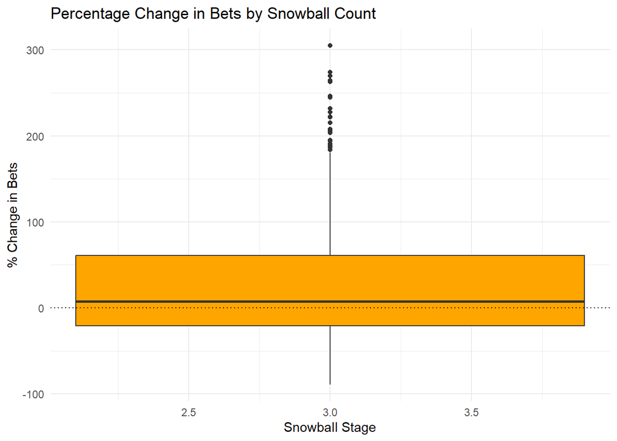

```r
snowball_df1 <- snowball_df %>%
  mutate(Bets.Percent.Change = ifelse(snowball != 0,
                                      Bets.Increment / lag(Total.Bets) * 100,
                                      0))
## Changes in Percentage Bets by Snowball Count ##
plot6_2 <- ggplot(snowball_df1 %>% filter(snowball != 0),
       aes(x = as.integer(snowball), y = Bets.Percent.Change,group=1)) +
  geom_boxplot(fill = "orange") +
  geom_hline(yintercept = 0, linetype = "dotted") +
  labs(title = "Percentage Change in Bets by Snowball Count",
       x = "Snowball Stage",
       y = "% Change in Bets") +
  theme_minimal()
plot6_2
```

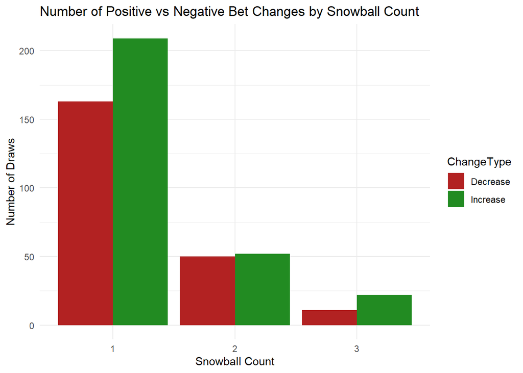

```r
## Number of Positive vs Negative Bet Changes by Snowball Count ##
plot6_3 <-snowball_df %>%
  filter(snowball != 0) %>%
  mutate(ChangeType = ifelse(Bets.Increment > 0, "Increase", "Decrease")) %>%
  group_by(snowball, ChangeType) %>%
  summarise(Count = n(), .groups = "drop") %>%
  ggplot(aes(x = as.factor(snowball), y = Count, fill = ChangeType)) +
  geom_col(position = "dodge") +
  labs(title = "Number of Positive vs Negative Bet Changes by Snowball Count",
       x = "Snowball Count",
       y = "Number of Draws") +
  scale_fill_manual(values = c("Increase" = "forestgreen", "Decrease" = "firebrick")) +
  theme_minimal()
plot6_3
```

### Question 7: What can Singapore Pools do increase their revenues? *

#### Before we can suggest, lets have a look at historical performance of Singapore Pool’s Revenue

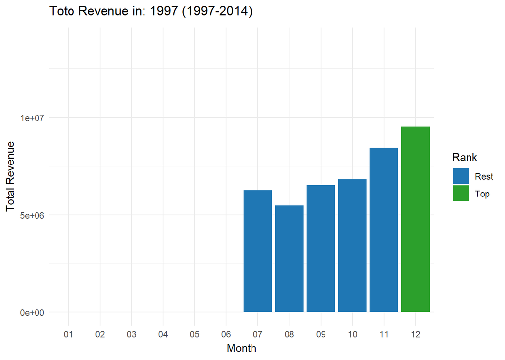

```r
### Assuming Group1.Prize = total bet amount = total revenue
plot5_revenue <- totoresults %>% mutate(Revenue = ifelse(Draw!=1,Group1.Prize-lag(Group1.Prize,default= first(Group1.Prize)),Group1.Prize)) %>% mutate(Date= as.Date(Date,format="%d/%m/%Y"),Year = as.integer(format(Date,"%Y")),Month = as.factor(format(Date,"%m")))

#Preparing Plot Dataset
plot5 <- plot5_revenue %>% group_by(Year,Month) %>% summarise(Total_Revenue = sum(Revenue)) %>% arrange(Year,Month)
plot5 <- plot5 %>% group_by(Year) %>% mutate(Rank=ifelse(Total_Revenue==max(Total_Revenue),"Top","Rest"))

#Plotting
p5 <- plot5 %>% ggplot(aes(x=Month,y=Total_Revenue,fill=Rank)) + geom_bar(stat='identity') + scale_fill_manual(values=c("Top"="#2ca02c","Rest"="#1f77b4"))
plot5 <- p5 + transition_time(Year) + labs(title="Toto Revenue in: {frame_time} (1997-2014)") + ylab("Total Revenue") +theme_minimal()
plot5
```

### 💡 **It is also important to see if there’s any relationship between the Number of Winners and the Total Bets placed in each month across the years.**💡

```r
#Monthly No. of winners from 1997 to 2014
winners_month <- betting.resultv2 %>% mutate(Month=month(ymd(Date)), Day = day(ymd(Date))) %>% group_by(Year,Month) %>% summarise(Winners = sum(No.Winners),No.of.Bets = sum(No.Bets)) %>% arrange(Year,Month)
```

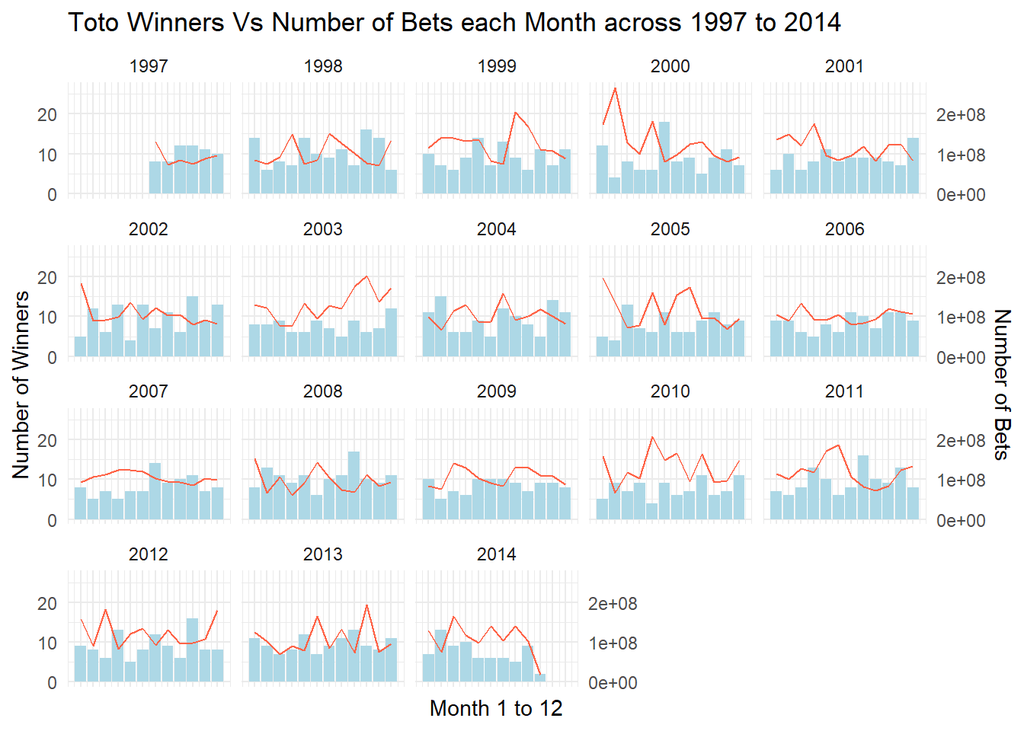

```r
#Preparing Plot Dataset
plot7 <- winners_month %>% ggplot(aes(x=Month)) + geom_col(aes(y=Winners),fill="lightblue") + geom_line(aes(y=No.of.Bets/10000000,group=1),color="tomato",size=0.5) + scale_y_continuous(name = "Number of Winners",sec.axis = sec_axis(~.* 10000000, name = "Number of Bets")) + scale_x_continuous(breaks=seq(1,12,by=1))+ labs(title = "Toto Winners Vs Number of Bets each Month across 1997 to 2014",x = "Month 1 to 12")+ theme_minimal() + facet_wrap(~Year)+ theme(axis.text.x = element_blank())

plot7
```

### Question 8: What are the key factors affecting TOTO revenues? *

#### *This question is closely related with the previous and on hindsight, it should have came before question 7. However, both can analysed simultaneously and reasonable recommendations could be derived from the results of their insights.*

```r
##### Ultimate Plot - To find out what contributes to Revenue Growth for Toto System #####

#Sorting out Dataset before Analysis
toto.R <- totoresults %>% mutate(bettingamount = ifelse(Draw!=1,Group1.Prize-lag(Group1.Prize,default= first(Group1.Prize)),Group1.Prize),Date=as.Date(Date,format="%d/%m/%Y"),snowball = as.factor(ifelse(Draw!=1,Draw-1,0)),Year=year(ymd(Date)),Month=month(ymd(Date)))

betting.R <- betting.resultv2 %>% mutate(Date=as.Date(Date,format="%Y-%m-%d")) %>% group_by(Date) %>% summarise(Total.Bets = sum(No.Bets))

#Merging Dataset
toto_betting <- toto.R %>% left_join(betting.R,by="Date")

#Preparing for Plot
plot8_df <- toto_betting %>% mutate(Month= as.factor(Month)) %>% select(Year,Month,Num.Winners,snowball,Group1.Prize,Total.Bets,bettingamount)

#Further Merging before conducting Model Fit to Multiple Linear Regression
plot8_df <- plot8_df %>% left_join(sg.gdp, by="Year")


#Model Fitting - MLR
model <- lm(log(Total.Bets) ~ Group1.Prize + snowball +Num.Winners + Month + Year + `GDP Per Capita`,data=plot8_df)
model1 <- lm(Total.Bets ~ Group1.Prize + snowball +Num.Winners + Month + Year + `GDP Per Capita`,data=plot8_df)
model2 <- lm(bettingamount ~ Group1.Prize + snowball +Num.Winners + Month + Year + `GDP Per Capita`,data=plot8_df)


#Plots

#Percentage Change in Total Bets (not absolute change)
plot8 <-model %>% tidy(conf.int = TRUE) %>% mutate(p.value = ifelse(p.value < 0.05, cell_spec(sprintf("%.4f", p.value), bold = T, color = "red"), sprintf("%.4f", p.value))) %>%
  kable("html", escape = F, digits = 4, caption = "Log-Transformed Total Bets - Regression Results",col.names = c("Variable", "Estimate", "Std. Error", "t Value", "P-Value", "95% CI Low", "95% CI High")) %>% kable_styling(bootstrap_options = c("striped", "hover", "condensed"),full_width = F,position = "center")
plot8
```

Log-Transformed Total Bets - Regression Results

| Variable | Estimate | Std. Error | t Value | P-Value | 95% CI Low | 95% CI High |
| --- | --- | --- | --- | --- | --- | --- |
| (Intercept) | 15.7704 | 16.9192 | 0.9321 | 0.3514 | -17.4131 | 48.9538 |
| Group1.Prize | 0.0000 | 0.0000 | 0.9204 | 0.3575 | 0.0000 | 0.0000 |
| snowball1 | -0.0254 | 0.0420 | -0.6037 | 0.5461 | -0.1078 | 0.0571 |
| snowball2 | -0.1009 | 0.0864 | -1.1673 | 0.2432 | -0.2704 | 0.0686 |
| snowball3 | -0.0028 | 0.1469 | -0.0193 | 0.9846 | -0.2909 | 0.2852 |
| Num.Winners | 0.0024 | 0.0137 | 0.1761 | 0.8603 | -0.0244 | 0.0292 |
| Month2 | -0.0903 | 0.0669 | -1.3499 | 0.1772 | -0.2216 | 0.0409 |
| Month3 | -0.0681 | 0.0649 | -1.0498 | 0.2939 | -0.1954 | 0.0591 |
| Month4 | -0.0951 | 0.0654 | -1.4532 | 0.1464 | -0.2234 | 0.0332 |
| Month5 | -0.0513 | 0.0649 | -0.7898 | 0.4297 | -0.1786 | 0.0760 |
| Month6 | -0.0787 | 0.0656 | -1.2001 | 0.2303 | -0.2072 | 0.0499 |
| Month7 | -0.1273 | 0.0640 | -1.9883 | 0.0469 | -0.2529 | -0.0017 |
| Month8 | -0.0764 | 0.0642 | -1.1900 | 0.2342 | -0.2024 | 0.0495 |
| Month9 | -0.1182 | 0.0645 | -1.8323 | 0.0671 | -0.2448 | 0.0083 |
| Month10 | -0.1169 | 0.0650 | -1.7988 | 0.0722 | -0.2443 | 0.0106 |
| Month11 | -0.1578 | 0.0655 | -2.4087 | 0.0161 | -0.2862 | -0.0293 |
| Month12 | -0.1151 | 0.0649 | -1.7724 | 0.0765 | -0.2425 | 0.0123 |
| Year | 0.0002 | 0.0085 | 0.0290 | 0.9769 | -0.0164 | 0.0169 |
| `GDP Per Capita` | 0.0000 | 0.0000 | -0.0558 | 0.9555 | 0.0000 | 0.0000 |

### Interpreting Multiple Linear Regression Result

| Finding | Evidence |
| --- | --- |
| 📉 November has lowest betting volume | Significant (p = 0.0161) |
| 📉 July also lower bets | Significant (p = 0.0469) |
| 📉 Months 9–12 show near-significant dips | Suggest seasonality |
| ❌ Jackpot size, winners, GDP have no effect | Not significant |
| ✅ Culture/habit/seasonality is key | Suggest Possibility of such influence |

Since from Month 1 - 12, the linear regression takes Month 1 as the benchmark reference hence Month 11 shows statistically significance in the betting volume being significantly lower as compared to Month 1 suggesting the possibility of seasonal/habit/culture betting behaviors from Punters. As also supported from Month 9-12 as well as no statiscal significance in Jackpot Size, No.of Winners and growth in GDP.

```r
#Absolute Number of Bets per draw
plot8_1 <- model1 %>% tidy(conf.int = TRUE) %>% mutate(p.value = ifelse(p.value < 0.05, cell_spec(sprintf("%.4f", p.value), bold = T, color = "red"), sprintf("%.4f", p.value))) %>%
  kable("html", escape = F, digits = 4, caption = "Raw Total Bets - Regression Results",col.names = c("Variable", "Estimate", "Std. Error", "t Value", "P-Value", "95% CI Low", "95% CI High")) %>% kable_styling(bootstrap_options = c("striped", "hover", "condensed"),full_width = F,position = "center")
plot8_1
```

Raw Total Bets - Regression Results

| Variable | Estimate | Std. Error | t Value | P-Value | 95% CI Low | 95% CI High |
| --- | --- | --- | --- | --- | --- | --- |
| (Intercept) | 22351169.0394 | 3.107375e+08 | 0.0719 | 0.9427 | -5.870969e+08 | 6.317992e+08 |
| Group1.Prize | 0.2580 | 4.160000e-01 | 0.6201 | 0.5353 | -5.580000e-01 | 1.073900e+00 |
| snowball1 | -150046.4504 | 7.719035e+05 | -0.1944 | 0.8459 | -1.663977e+06 | 1.363884e+06 |
| snowball2 | -1818935.2246 | 1.587423e+06 | -1.1458 | 0.2520 | -4.932341e+06 | 1.294471e+06 |
| snowball3 | 1509712.0139 | 2.697543e+06 | 0.5597 | 0.5758 | -3.780967e+06 | 6.800391e+06 |
| Num.Winners | 153314.6600 | 2.511021e+05 | 0.6106 | 0.5416 | -3.391707e+05 | 6.458001e+05 |
| Month2 | -1558170.5800 | 1.228869e+06 | -1.2680 | 0.2050 | -3.968346e+06 | 8.520047e+05 |
| Month3 | -1585612.1887 | 1.191763e+06 | -1.3305 | 0.1835 | -3.923010e+06 | 7.517861e+05 |
| Month4 | -2001098.7365 | 1.201714e+06 | -1.6652 | 0.0960 | -4.358016e+06 | 3.558183e+05 |
| Month5 | -1010717.1778 | 1.192206e+06 | -0.8478 | 0.3967 | -3.348984e+06 | 1.327550e+06 |
| Month6 | -1535044.4751 | 1.203964e+06 | -1.2750 | 0.2025 | -3.896374e+06 | 8.262849e+05 |
| Month7 | -2083144.7160 | 1.176144e+06 | -1.7712 | 0.0767 | -4.389911e+06 | 2.236218e+05 |
| Month8 | -1444573.1043 | 1.179820e+06 | -1.2244 | 0.2210 | -3.758549e+06 | 8.694024e+05 |
| Month9 | -2293728.0188 | 1.185101e+06 | -1.9355 | 0.0531 | -4.618061e+06 | 3.060538e+04 |
| Month10 | -2321422.9668 | 1.193291e+06 | -1.9454 | 0.0519 | -4.661819e+06 | 1.897304e+04 |
| Month11 | -3273241.3315 | 1.202952e+06 | -2.7210 | 0.0066 | -5.632586e+06 | -9.138964e+05 |
| Month12 | -2443161.2230 | 1.192711e+06 | -2.0484 | 0.0407 | -4.782421e+06 | -1.039018e+05 |
| Year | -4029.1952 | 1.559299e+05 | -0.0258 | 0.9794 | -3.098538e+05 | 3.017954e+05 |
| `GDP Per Capita` | 3.4734 | 5.989650e+01 | 0.0580 | 0.9538 | -1.140013e+02 | 1.209481e+02 |

### Interpreting Multiple Linear Regression Result

| Variable | Effect on Bets | Statistically Significant? | Interpretation |
| --- | --- | --- | --- |
| Group1.Prize | +0.258 | ❌ (p = 0.53) | No effect |
| snowball1–3 | Mixed, all ❌ | ❌ | No effect |
| Num.Winners | +153k | ❌ (p = 0.54) | No effect |
| Month11 (Nov) | –3.27 million | ✅ (p = 0.0066) | Fewer bets |
| Month12 (Dec) | –2.44 million | ✅ (p = 0.0407) | Fewer bets |
| Month9–10 | ~–2.3 million | ⚠️ (p = 0.05x) | Possibly fewer bets |
| GDP per Capita | +3.47 | ❌ (p = 0.95) | No effect |
| Year | ~0 | ❌ | No trend |

Similar to previous Multiple Linear Regression since this is just taking the raw bets which the results are as expected. However this regression result is susceptible to outliers and may be noisier compared to previous transformed regression.

```r
#Change in Prize Pool Value (for revenue)
plot8_2 <- model2 %>% tidy(conf.int = TRUE) %>% mutate(p.value = ifelse(p.value < 0.05, cell_spec(sprintf("%.4f", p.value), bold = T, color = "red"), sprintf("%.4f", p.value))) %>%
  kable("html", escape = F, digits = 4, caption = "Derived Revenue (Prize delta) - Regression Results",col.names = c("Variable", "Estimate", "Std. Error", "t Value", "P-Value", "95% CI Low", "95% CI High")) %>% kable_styling(bootstrap_options = c("striped", "hover", "condensed"),full_width = F,position = "center")
plot8_2
```

Derived Revenue (Prize delta) - Regression Results

| Variable | Estimate | Std. Error | t Value | P-Value | 95% CI Low | 95% CI High |
| --- | --- | --- | --- | --- | --- | --- |
| (Intercept) | -3228609.8007 | 2903343.0666 | -1.1120 | 0.2663 | -8922923.1062 | 2465703.5048 |
| Group1.Prize | 1.0073 | 0.0039 | 259.1550 | 0.0000 | 0.9997 | 1.0150 |
| snowball1 | -713279.2610 | 7212.1988 | -98.8990 | 0.0000 | -727424.5131 | -699134.0089 |
| snowball2 | -1813718.7218 | 14831.9218 | -122.2848 | 0.0000 | -1842808.5013 | -1784628.9423 |
| snowball3 | -3506839.8817 | 25204.2093 | -139.1371 | 0.0000 | -3556272.7807 | -3457406.9827 |
| Num.Winners | -3853.5787 | 2346.1460 | -1.6425 | 0.1007 | -8455.0640 | 747.9066 |
| Month2 | -5318.1081 | 11481.8087 | -0.4632 | 0.6433 | -27837.3263 | 17201.1102 |
| Month3 | 16696.0530 | 11135.1072 | 1.4994 | 0.1339 | -5143.1811 | 38535.2872 |
| Month4 | 1942.7436 | 11228.0922 | 0.1730 | 0.8627 | -20078.8615 | 23964.3488 |
| Month5 | 15009.0391 | 11139.2468 | 1.3474 | 0.1780 | -6838.3139 | 36856.3922 |
| Month6 | 19339.8726 | 11249.1121 | 1.7192 | 0.0857 | -2722.9589 | 41402.7041 |
| Month7 | 18655.4418 | 10989.1810 | 1.6976 | 0.0898 | -2897.5879 | 40208.4715 |
| Month8 | 27006.1119 | 11023.5238 | 2.4499 | 0.0144 | 5385.7258 | 48626.4980 |
| Month9 | 18878.9530 | 11072.8675 | 1.7050 | 0.0884 | -2838.2107 | 40596.1167 |
| Month10 | 22348.5207 | 11149.3879 | 2.0045 | 0.0452 | 481.2778 | 44215.7636 |
| Month11 | 20829.2906 | 11239.6585 | 1.8532 | 0.0640 | -1214.9995 | 42873.5807 |
| Month12 | 79.8453 | 11143.9736 | 0.0072 | 0.9943 | -21776.7786 | 21936.4691 |
| Year | 1610.4972 | 1456.9146 | 1.1054 | 0.2691 | -1246.9428 | 4467.9371 |
| `GDP Per Capita` | -0.4466 | 0.5596 | -0.7980 | 0.4250 | -1.5442 | 0.6510 |

### Interpreting Multiple Linear Regression Result

| Variable | Effect on `bettingamount` | Interpretation |
| --- | --- | --- |
| `Group1.Prize` | +$1.007 per $1 | Basically defines `bettingamount` — **not an independent variable** |
| `snowball1–3` | Strong negative | Rollovers inflate prize, but lower **fresh revenue** seen that draw |
| `Month8`, `10` | Positive, significant | More betting activity → higher revenue in Aug and Oct |
| Other months | Small effects | Suggest seasonality but not strong enough to stand on their own statistically |
| `GDP`, `Year` | No significant impact | Consistent with earlier models |

Before any interpretation, it is important to duly note that the **target variable is derived and assumed** that the Group1.Prize is the total revenue that Toto receives. (Group1.Prize = Revenue aft deducting snowballed amount). However, before each draw, the total betting amount are totaled and distributed into groups as shown in the table provided at the start. **Group1 Prize only consist of 33% of the Prize Pool.**

| ❗ Problem Type | 🔍 Description |
| --- | --- |
| **1. Circularity / Tautology** | The target variable (`bettingamount`) is derived directly from `Group1.Prize`. The model is explaining a variable using itself, which inflates model fit. |
| **2. Misleading Proxy for Revenue** | `Group1.Prize` represents only ~33% of the prize pool and doesn’t reflect total bet revenue, making it an unreliable measure of punter activity. |
| **3. Multicollinearity** | Strong correlation between predictors (e.g. `Group1.Prize` and `snowball`) can lead to unstable estimates and inflated standard errors. |
| **4. Game Structure Bias** | Toto’s payout system is complex, with pooled prizes and multiple winning groups. Modeling only Group 1 ignores these structural dynamics. |
| **5. Heteroskedasticity** | The variance of residuals may not be constant, especially during snowball periods, which violates linear regression assumptions. |
| **6. GDP & Year Irrelevance** | Including predictors with no explanatory power (like GDP per capita or Year) introduces noise and adds unnecessary complexity. |

## **Conclusion**

Based on the analysis, several key observations emerge — keeping in mind the limitations of the dataset and the assumptions of fairness in the game design. The results suggest that Toto betting behavior is driven less by rational economic factors and more by cultural, seasonal, and habitual patterns.

This reinforces the idea that Toto functions not just as a lottery game, but as a social and cultural fixture, especially for regular and seasonal punters. To maintain or increase engagement, Toto may benefit from designing new game formats, special seasonal draws, or promotional events that tap into habitual and festive betting behaviors throughout the year.

Finally, it is important to recall that Toto was originally introduced as a legal alternative to illegal gambling in Singapore. If it fails to remain engaging or credible, punters may seek alternative, unregulated avenues — undermining the very objective Toto was created to serve.

For educational purposes, a Toto simulation was posted on Reddit by user: Rekane https://www.reddit.com/r/singapore/comments/al5q7p/i_updated_the_toto_simulator/

After playing with the simulator, it is more often that we land ourselves in a huge debt before we can even live to the day we hit a jackpot assuming we bet everyday. Even if System 12 Bet is played, there’s a chance the jackpot cannot cover the loss or that the profit only comes in after 44 years (If lucky)

*Analysis Done By: Patrick Tan*